# Hooking Mortality

Page Last Updated: 11/24/2021.

# Load Functions

```r
wd_functions<-"functions"
sapply(FUN = source, paste(wd_functions, list.files(wd_functions), sep="/"))
```

# Install & Load Packages

This section of code will load the packages we need to complete the analysis

```r
packages_list<-c("tidyverse", "plyr","dplyr", "lubridate","tidyr","scales","RODBC","MuMIn","RColorBrewer","reshape2","ggplot2","gplots","mgcv","sjPlot","sjmisc","gridExtra","modelr","kableExtra","dataRetrieval","MASS","brms","rstan","sf","riverdist","maptools","rgdal","raster","rgeos")
install_or_load_pack(pack = packages_list)
```

# Read and organize data

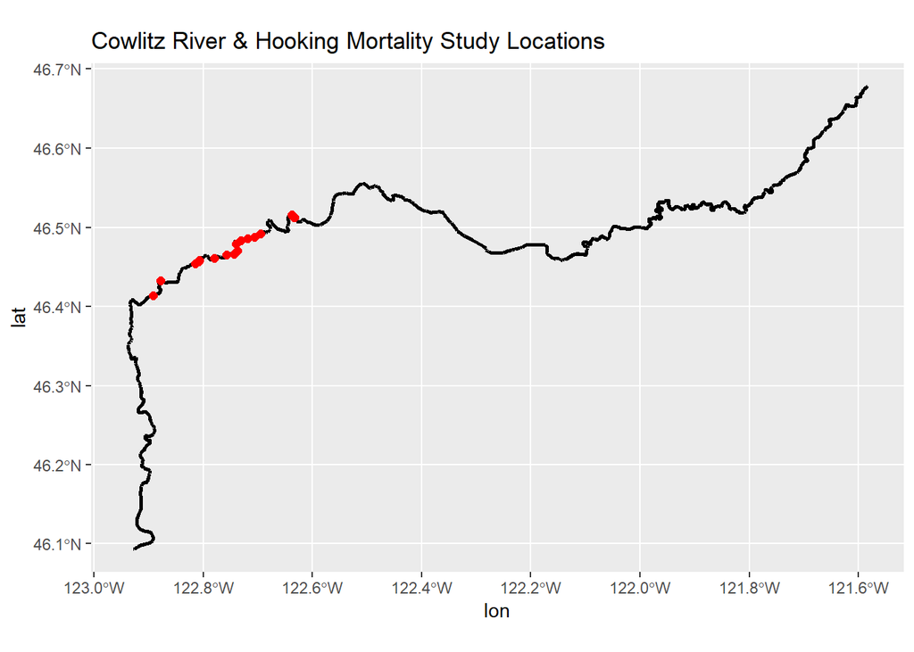

```r
#locations from table
location.df<-odbc(accdb.name="CowlitzHookingMortalityDB.accdb",db.dir=getwd(),dsn="MS Access Database", sqtable="Location Index", fields= "*")%>%
  as_tibble()%>%
  mutate(lat=ifelse(!is.na(Loc_Lat),Loc_Lat,(US_Lat + DS_Lat)/2),
         lon=ifelse(!is.na(Loc_Lon),Loc_Lon,(US_Lon + DS_Lon)/2)
         )%>%
  filter(!is.na(lat))%>%
  dplyr::select(`Location Name`,lat,lon)

points.dec = SpatialPoints(cbind(location.df$lon, location.df$lat), proj4string=CRS("+proj=longlat"))

#cowlitz flow line shape file
river.sh<-st_read("WA_Hydrography_-_NHD_Flowline/WA_Hydrography_-_NHD_Flowline.shp")
points.plot <- data.frame(spTransform(points.dec, crs(river.sh)))%>%
  dplyr::rename(lon=coords.x1,lat=coords.x2)

#Map river with locations
ggplot() +
  geom_sf(data = river.sh, size = 1, color = "black", fill = "cyan1") +
  ggtitle("Cowlitz River & Hooking Mortality Study Locations") +
  coord_sf()+
  geom_point(data=points.plot,mapping=aes(x=lon,y=lat),color="red",size=2)
```

```r
river_sp<-readShapeLines(
  fn="WA_Hydrography_-_NHD_Flowline/WA_Hydrography_-_NHD_Flowline.shp",
  proj4string=CRS("+proj=merc +a=6378137 +b=6378137 +lat_ts=0 +lon_0=0 +x_0=0 +y_0=0 +k=1 +units=m +nadgrids=@null +wktext +no_defs ")
  , verbose=FALSE
  ,repair=FALSE
  ,delete_null_obj=FALSE
  )

river<-line2network(
  sp = river_sp,
  path = ".",
  layer = NA,
  tolerance = 100,
  reproject = NULL,
  supplyprojection = NULL
)

river_2<-setmouth(seg=354, vert=1, rivers=river)
#showends(seg=354,rivers=river)


points.UTM <- spTransform(points.dec, crs(river_sp))
points<-xy2segvert(x=points.UTM$coords.x1,y=points.UTM$coords.x2,rivers=river_2)

#plot(river)
#riverpoints(seg=points$seg, vert=points$vert, rivers=river, pch=15,col="blue")

RKM<-mouthdistbysurvey(
  unique=1:dim(points)[1],
  survey=rep(1,dim(points)[1]),
  seg=points$seg,
  vert=points$vert,
  rivers = river_2,
  logical = NULL,
  stopiferror = TRUE,
  algorithm = NULL
)/1000

location.df<-location.df%>%
  bind_cols(RKM=RKM)


# all captures
capture.df<-odbc(accdb.name="CowlitzHookingMortalityDB.accdb",db.dir=getwd(),dsn="MS Access Database", sqtable="All Captures Query", fields= "*")%>%
  as_tibble()%>%
  mutate(
    Year = as.numeric(year(ymd(as.character(Survey_Date)))),
    Month = as.numeric(month(ymd(as.character(Survey_Date)))),
    jdate = as.numeric(julian(ymd(as.character(Survey_Date)))),
    DOY = as.numeric(yday(ymd(as.character(Survey_Date)))),
    Capture_Type = ifelse(Capcode=="0", "No_Captures",
                                 ifelse(Capcode=="1", "New_Fish",
                                    ifelse(Capcode=="2", "Recapture",
                                      ifelse(Capcode=="3", "Natural_Origin",
                                        ifelse(Capcode=="5", "New_Fish","Lost"))))), #all variants of Capcode 4 were lost (we may want to differentiate for some analyses)
     #define initial capture as a control or treatment
    Treatment = ifelse(Survey_type%in%c("Control Release TP","Control Release MHE","Control Recycle"), "Control",
                                ifelse(Survey_type=="Angling", "Treatment","Other")),
    run_year = as.numeric(ifelse(as.numeric(Year=="2017")&as.numeric(Month>8)&SpeciesCode=="COHO","2017",
                               ifelse(as.numeric(Year=="2018")&as.numeric(Month<5)&SpeciesCode=="COHO","2017",
                                      ifelse(as.numeric(Year=="2018")&as.numeric(Month>8)&SpeciesCode=="COHO","2018",
                                             ifelse(as.numeric(Year=="2019")&as.numeric(Month<5)&SpeciesCode=="COHO","2018",
                                                    ifelse(as.numeric(Year=="2019")&as.numeric(Month>8)&SpeciesCode=="COHO","2019",
                                                           ifelse(as.numeric(Year=="2020")&as.numeric(Month<5)&SpeciesCode=="COHO","2019",
                                                                  ifelse(as.numeric(Year=="2017")&SpeciesCode=="STLHD","2017",
                                                                         ifelse(as.numeric(Year=="2018")&SpeciesCode=="STLHD","2018",
                                                                                ifelse(as.numeric(Year=="2019")&SpeciesCode=="STLHD","2019",
                                                                                       ifelse(as.numeric(Year=="2020")&as.numeric(Month<2)&SpeciesCode=="STLHD","2019",
                                                                                              ifelse(as.numeric(Year=="2020")&as.numeric(Month>2)&SpeciesCode=="STLHD","2020",as.numeric(Year))))))))))))
  ))%>%left_join(location.df,by=c(Release_Location="Location Name"))

#only first captures that were new fish (T or C)
firstcapture = capture.df%>%
  filter(Capcode=="1"|Capcode =="5") #these are initial captures and excludes Capcode 3s and 4s

#only first recaptures
recapture = capture.df%>%
  filter(Capcode=="2")%>%
  group_by(Fish_ID)%>%
  arrange(Survey_Date,TimeCapture)%>%
  slice(1L) #get first data/time recapure for each fish ID

#merge capture-recapture & create dummy variable for recaptures
dat<-firstcapture%>%
  left_join(recapture, by="Fish_ID",suffix=c("_cap","_recap"))%>%
  mutate(rec=ifelse(!is.na(DOY_recap),1,0))#join first captures with first recaptures
```

# NOTES

### Analysis

Options for Analysis: 1. Binomial-logit with dummy variable with dummy variable for TC 2. Split binomial R2R 3. Time to recovery (survival analysis)

Things to explore in analysis 1. Including Capcode as a factor variable in the treatment effects would test for an “unaccounted for” control effect; Cap-code 5 would be lower recovery rate if unaccounted effect.

### Notes on Data and Database:

1. Added lat/long to database for Barrier Dam (missing originally)
2. Maybe need to exclude control Capcode 2 and 5’s that were released in upper basin/brood first? 1 present in coho, several spring Chinook.
- Capcodes really important
  - Filter out capcode 0’s
  - Filter out wild fish
  - Capcode 5 = fish that went from control release to treatment fish
    - Initially tags pulled and new floys put in fish
    - Later, fish simply release with old floys
- Multiple recap fish
  - Make sure to filter for initial releases and only “count” single recapture
- Consider removint fish that aren’t available for recapture
  - Capcode 1—look for “loss on capture” (mortality) in both treatments and controls
  - (only 5 controls died)
- Look for errata
  - Example: fish that had no release record but were recovered, we created a release record

### Thomas Musing’s on analysis

- For coho and spring chinook, it’s relatively trivial…we basically have day of year and year (year only for coho) that can affect recovery rates, because we released basically all the controls at barrier pool…nice simple clean study design with not *too many* possible competing models
- For steelhead, we released controls at multiple locations AND the hatchery (where fish presumably home) is not adjacent to the principle recovery location (separator). We have to at least consider trying to account for year effects, day of year effects, river kilometer of release effects, and possible 2- and 3-way interactions. Since many of these are expected to be non-linear, I used splines. When you add the number of candidate models with just combinations of main effects and interactions it is a lot of models. Then you can consider the spline hyperparameters (basis function type, number of knots, penalty order) and the number of candidate models is huge. I can up with an approach that simplifies this a bit by basically factoring out year (using “by” in spline notation), so that effects were independent by year. That said, I am still thinking on how to “simplify” the spline analysis for non-linear effects affecting capture probabilities for controls…want a defensible final model without exhaustively testing 1000’s of models (and thereby likely finding one that isn’t the best anyway!). I think my default idea is to basically fit a “full” penalized model for all variables possibly affecting control recoveries, knowing not all variables may be “significant” but by penalizing, it won’t be overfitting, and we aren’t really interested in hypothesis testing control variables anyway…just controlling for their effects.

# GAM analysis of factors affecting prob of recapture for control Coho

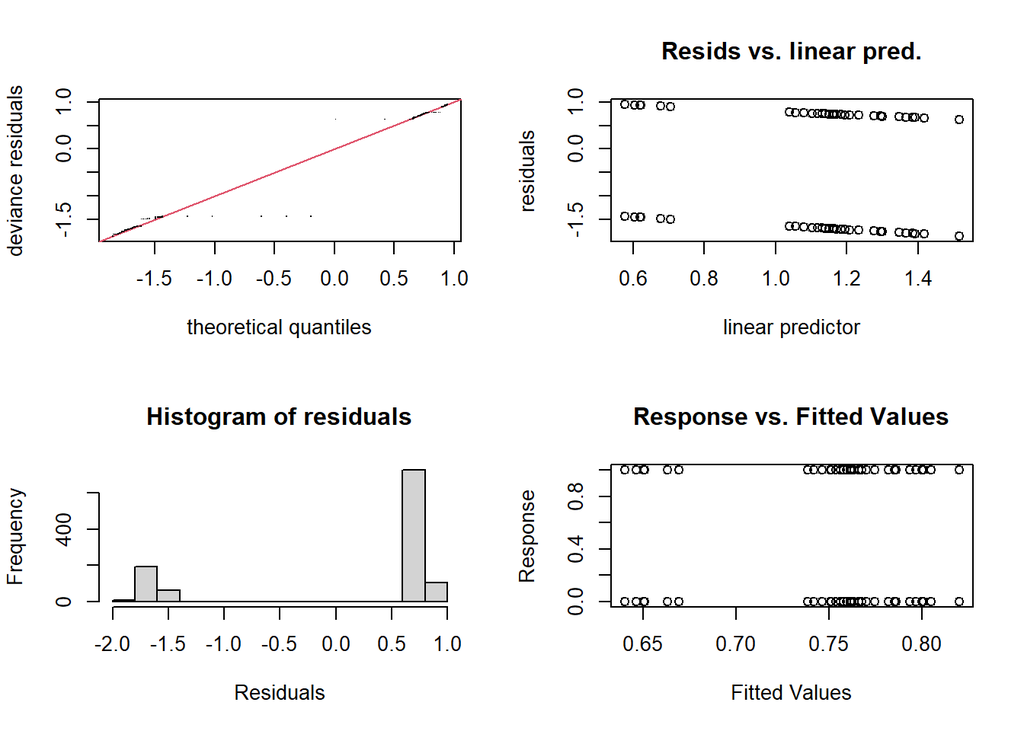

```r
cdat<-dat%>%
  filter(SpeciesCode_cap=="COHO" & Treatment_cap=="Control")%>%
  dplyr::select(
    rec,
    Fish_ID,
    run_year_cap,
    DOY_cap,
    Temp_C_cap,
    Release_Location_cap,
    Capture_Location_recap,
    survey_ID_cap
                )%>%
  mutate(run_year_cap = factor(run_year_cap))

m1<-gam(rec ~
          1
          + s(run_year_cap,bs="re")
          + s(DOY_cap,by=run_year_cap,k=20,m=1)
          + s(survey_ID_cap,bs="re",m=1)
          ,family = binomial(link="logit")
          ,data=cdat
    )

cat("\\begin{verbatim}")
cat(print("Summary GAM results for probability of recapture for control coho"))
try(cat(print(summary(m1)),silent = T))
cat(print("GAM Goodness of Fit check for probability of recapture for control coho"))
try(cat(print(gam.check(m1)),silent = T))
```

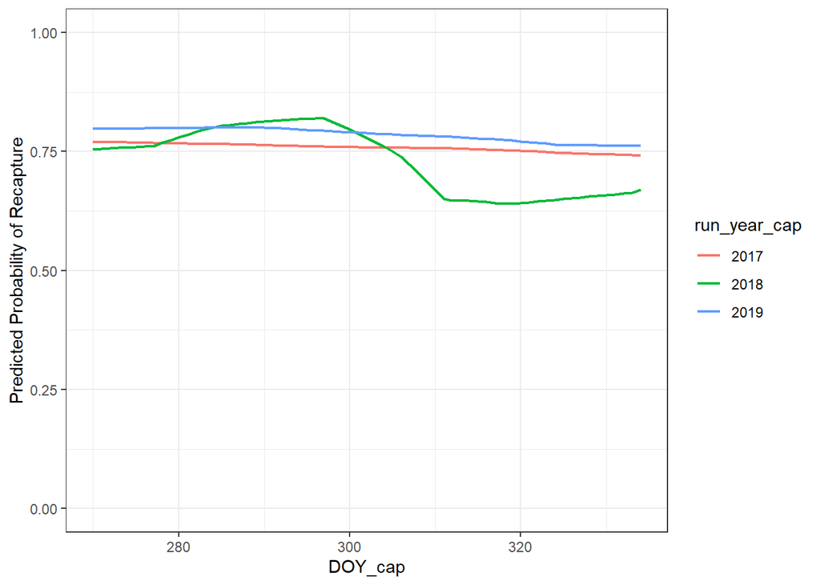

```
## \begin{verbatim}[1] "Summary GAM results for probability of recapture for control coho"
## Summary GAM results for probability of recapture for control coho
## Family: binomial
## Link function: logit
##
## Formula:
## rec ~ 1 + s(run_year_cap, bs = "re") + s(DOY_cap, by = run_year_cap,
##     k = 20, m = 1) + s(survey_ID_cap, bs = "re", m = 1)
##
## Parametric coefficients:
##             Estimate Std. Error z value Pr(>|z|)
## (Intercept)   1.1587     0.1145   10.12   <2e-16 ***
## ---
## Signif. codes:  0 '***' 0.001 '**' 0.01 '*' 0.05 '.' 0.1 ' ' 1
##
## Approximate significance of smooth terms:
##                                   edf Ref.df Chi.sq p-value
## s(run_year_cap)             1.1888398      2  3.874 0.03449 *
## s(DOY_cap):run_year_cap2017 0.4894167     10  0.639 0.24037
## s(DOY_cap):run_year_cap2018 3.7680170     14 13.283 0.00221 **
## s(DOY_cap):run_year_cap2019 0.7158589      8  1.152 0.16609
## s(survey_ID_cap)            0.0003336      1  0.000 0.60732
## ---
## Signif. codes:  0 '***' 0.001 '**' 0.01 '*' 0.05 '.' 0.1 ' ' 1
##
## R-sq.(adj) =  0.0198   Deviance explained = 2.19%
## UBRE = 0.099186  Scale est. = 1         n = 1096
## Error in cat(print(summary(m1)), silent = T) :
##   argument 1 (type 'list') cannot be handled by 'cat'
## [1] "GAM Goodness of Fit check for probability of recapture for control coho"
## GAM Goodness of Fit check for probability of recapture for control coho
## Method: UBRE   Optimizer: outer newton
## full convergence after 9 iterations.
## Gradient range [-4.18782e-07,1.641765e-08]
## (score 0.09918607 & scale 1).
## Hessian positive definite, eigenvalue range [4.185163e-07,0.001906675].
## Model rank =  62 / 62
##
## Basis dimension (k) checking results. Low p-value (k-index<1) may
## indicate that k is too low, especially if edf is close to k'.
##
##                                   k'      edf k-index p-value
## s(run_year_cap)             3.00e+00 1.19e+00      NA      NA
## s(DOY_cap):run_year_cap2017 1.90e+01 4.89e-01    0.95    0.19
## s(DOY_cap):run_year_cap2018 1.90e+01 3.77e+00    0.95    0.20
## s(DOY_cap):run_year_cap2019 1.90e+01 7.16e-01    0.95    0.17
## s(survey_ID_cap)            1.00e+00 3.34e-04    0.95    0.19
## $mfrow
## [1] 2 2
##
## Error in cat(print(gam.check(m1)), silent = T) :
##   argument 1 (type 'list') cannot be handled by 'cat'
## \end{verbatim}
```

```r
cat("\\end{verbatim}")


newdat<-expand.grid(
  DOY_cap = seq(from=min(cdat$DOY_cap),to=max(cdat$DOY_cap)),
  run_year_cap = unique(cdat$run_year_cap),
  survey_ID_cap = 0
  )%>%
  as_tibble()

preds=data.frame(preds=predict(newdata=newdat,m1,var="preds",type = "response", exclude = '(survey_ID_cap,bs="re",m=1)'))%>%
  as_tibble()

newdat<-newdat%>%
  bind_cols(preds)

ggplot(newdat,aes(x=DOY_cap,y=preds,color=run_year_cap))+
  geom_line(size=0.8)+
  ylim(0,1)+
  ylab("Predicted Probability of Recapture")+
  theme_bw()
```

# GAM analysis of factors affecting prob of recapture for Summer Steelhead

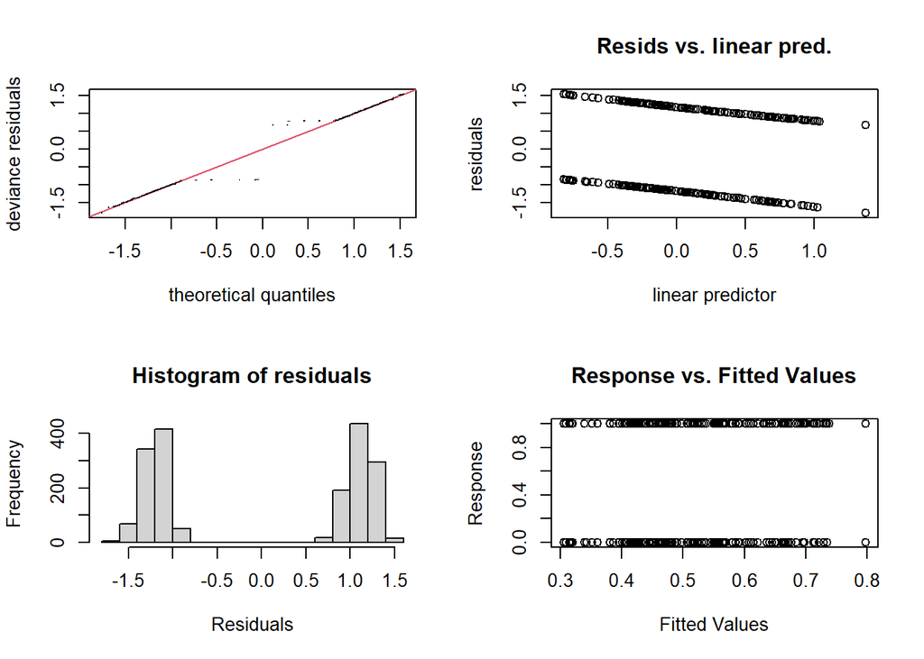

```r
cdat<-dat%>%
  filter(SpeciesCode_cap=="STLHD" & Treatment_cap=="Control")%>%
  dplyr::select(
    rec,
    Fish_ID,
    run_year_cap,
    DOY_cap,
    Temp_C_cap,
    Release_Location_cap,
    RKM_cap,
    Capture_Location_recap,
    survey_ID_cap
                )%>%
  mutate(run_year_cap = factor(run_year_cap))

m1<-gam(rec ~
          1
          + s(run_year_cap,bs="re")
          + s(DOY_cap,by=run_year_cap,bs="ps",k=5,m=1)
          + s(RKM_cap,by=run_year_cap,bs="ps",k=3,m=1)
          + ti(RKM_cap,DOY_cap,by=run_year_cap,bs="ps",k=4)
          + s(survey_ID_cap,bs="re",m=1)
          + RKM_cap
          ,family = binomial(link="logit")
          ,data=cdat
    )

cat("\\begin{verbatim}")
cat(print("Summary GAM results for probability of recapture for control coho"))
try(cat(print(summary(m1)),silent = T))
cat(print("GAM Goodness of Fit check for probability of recapture for control coho"))
try(cat(print(gam.check(m1)),silent = T))
```

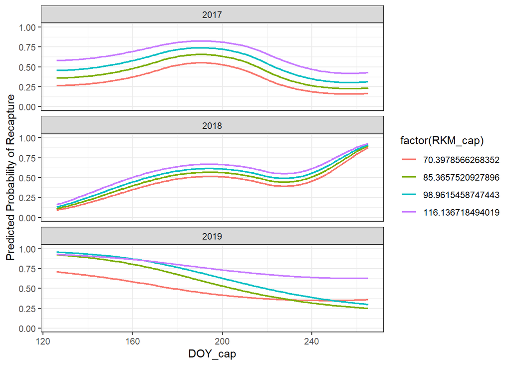

```
## \begin{verbatim}[1] "Summary GAM results for probability of recapture for control coho"
## Summary GAM results for probability of recapture for control coho
## Family: binomial
## Link function: logit
##
## Formula:
## rec ~ 1 + s(run_year_cap, bs = "re") + s(DOY_cap, by = run_year_cap,
##     bs = "ps", k = 5, m = 1) + s(RKM_cap, by = run_year_cap,
##     bs = "ps", k = 3, m = 1) + ti(RKM_cap, DOY_cap, by = run_year_cap,
##     bs = "ps", k = 4) + s(survey_ID_cap, bs = "re", m = 1) +
##     RKM_cap
##
## Parametric coefficients:
##              Estimate Std. Error z value Pr(>|z|)
## (Intercept) -2.360976   0.558177  -4.230 2.34e-05 ***
## RKM_cap      0.029285   0.006713   4.362 1.29e-05 ***
## ---
## Signif. codes:  0 '***' 0.001 '**' 0.01 '*' 0.05 '.' 0.1 ' ' 1
##
## Approximate significance of smooth terms:
##                                            edf Ref.df Chi.sq  p-value
## s(run_year_cap)                      2.263e-04      2  0.000   0.1910
## s(DOY_cap):run_year_cap2017          2.570e+00      4 19.267 3.95e-05 ***
## s(DOY_cap):run_year_cap2018          3.019e+00      4  8.588   0.0265 *
## s(DOY_cap):run_year_cap2019          1.964e+00      4 34.482  < 2e-16 ***
## s(RKM_cap):run_year_cap2017          1.180e-04      2  0.000   0.9734
## s(RKM_cap):run_year_cap2018          1.071e+00      2  4.426   0.0187 *
## s(RKM_cap):run_year_cap2019          1.837e-04      2  0.000   0.3436
## ti(RKM_cap,DOY_cap):run_year_cap2017 1.986e-04      7  0.000   0.6681
## ti(RKM_cap,DOY_cap):run_year_cap2018 2.476e-05      8  0.000   0.4588
## ti(RKM_cap,DOY_cap):run_year_cap2019 8.890e-01      6  2.543   0.0503 .
## s(survey_ID_cap)                     6.334e-01      1  1.681   0.1003
## ---
## Signif. codes:  0 '***' 0.001 '**' 0.01 '*' 0.05 '.' 0.1 ' ' 1
##
## R-sq.(adj) =  0.034   Deviance explained = 2.95%
## UBRE = 0.35722  Scale est. = 1         n = 1832
## Error in cat(print(summary(m1)), silent = T) :
##   argument 1 (type 'list') cannot be handled by 'cat'
## [1] "GAM Goodness of Fit check for probability of recapture for control coho"
```

[output cut: 14 more lines]

```
## s(DOY_cap):run_year_cap2018          4.00e+00 3.02e+00    0.98    0.16
## s(DOY_cap):run_year_cap2019          4.00e+00 1.96e+00    0.98    0.16
## s(RKM_cap):run_year_cap2017          2.00e+00 1.18e-04    0.98    0.23
## s(RKM_cap):run_year_cap2018          2.00e+00 1.07e+00    0.98    0.24
## s(RKM_cap):run_year_cap2019          2.00e+00 1.84e-04    0.98    0.23
## ti(RKM_cap,DOY_cap):run_year_cap2017 7.00e+00 1.99e-04    1.02    0.92
## ti(RKM_cap,DOY_cap):run_year_cap2018 8.00e+00 2.48e-05    1.02    0.88
## ti(RKM_cap,DOY_cap):run_year_cap2019 7.00e+00 8.89e-01    1.02    0.92
## s(survey_ID_cap)                     1.00e+00 6.33e-01    0.98    0.16
## $mfrow
## [1] 2 2
##
## Error in cat(print(gam.check(m1)), silent = T) :
##   argument 1 (type 'list') cannot be handled by 'cat'
## \end{verbatim}
```

```r
cat("\\end{verbatim}")


newdat<-expand.grid(
  DOY_cap = seq(from=min(cdat$DOY_cap),to=max(cdat$DOY_cap)),
  run_year_cap = unique(cdat$run_year_cap),
  RKM_cap = unique(cdat$RKM_cap),
  survey_ID_cap = 0
  )%>%
  as_tibble()

preds=data.frame(preds=predict(newdata=newdat,m1,var="preds",type = "response", exclude = '(survey_ID_cap,bs="re",m=1)'))%>%
  as_tibble()

newdat<-newdat%>%
  bind_cols(preds)


ggplot(newdat,aes(x=DOY_cap,y=preds,color=factor(RKM_cap)))+
  geom_line(size=0.8)+
  facet_wrap(~run_year_cap,ncol=1)+
  ylim(0,1)+
  ylab("Predicted Probability of Recapture")+
  theme_bw()
```

# GAM analysis of factors affecting prob of recapture for Winter Steelhead

NOTE: analysis NOT final…still lack of fit for tensor product interaction term…need to examine residuals…steelhead data funky as expected…possibly filter recovery locations to separator.

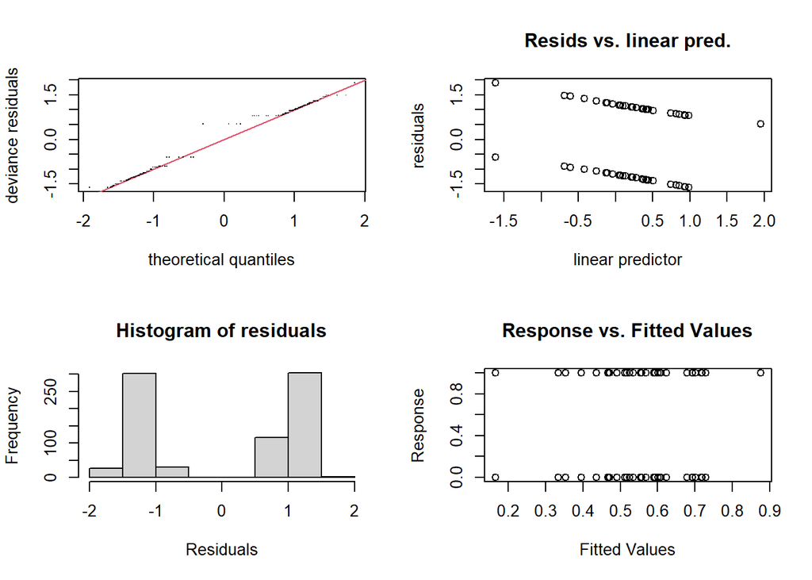

```r
cdat<-dat%>%
  filter(SpeciesCode_cap=="WSTLHD" & Treatment_cap=="Control")%>%
  dplyr::select(
    rec,
    Fish_ID,
    run_year_cap,
    DOY_cap,
    Temp_C_cap,
    Release_Location_cap,
    RKM_cap,
    Capture_Location_recap,
    survey_ID_cap
                )%>%
  mutate(run_year_cap = factor(run_year_cap))

m1<-gam(rec ~
          1
          + s(run_year_cap,bs="re")
          + s(DOY_cap,by=run_year_cap,bs="ps",k=10,m=1)
          + s(RKM_cap,by=run_year_cap,bs="ps",k=3,m=1)
          + ti(RKM_cap,DOY_cap,by=run_year_cap,bs="ps",k=12,m=2)
          + s(survey_ID_cap,bs="re",m=1)
          + RKM_cap
          ,family = binomial(link="logit")
          ,data=cdat
    )

cat("\\begin{verbatim}")
cat(print("Summary GAM results for probability of recapture for control coho"))
try(cat(print(summary(m1)),silent = T))
cat(print("GAM Goodness of Fit check for probability of recapture for control coho"))
try(cat(print(gam.check(m1)),silent = T))
```

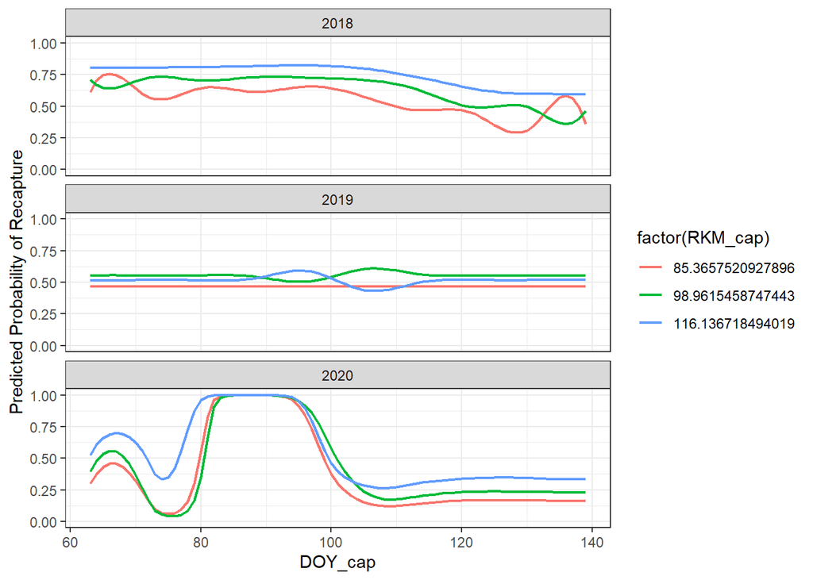

```
## \begin{verbatim}[1] "Summary GAM results for probability of recapture for control coho"
## Summary GAM results for probability of recapture for control coho
## Family: binomial
## Link function: logit
##
## Formula:
## rec ~ 1 + s(run_year_cap, bs = "re") + s(DOY_cap, by = run_year_cap,
##     bs = "ps", k = 10, m = 1) + s(RKM_cap, by = run_year_cap,
##     bs = "ps", k = 3, m = 1) + ti(RKM_cap, DOY_cap, by = run_year_cap,
##     bs = "ps", k = 12, m = 2) + s(survey_ID_cap, bs = "re", m = 1) +
##     RKM_cap
##
## Parametric coefficients:
##             Estimate Std. Error z value Pr(>|z|)
## (Intercept) -2.74073   46.83130  -0.059   0.9533
## RKM_cap      0.03106    0.01695   1.833   0.0668 .
## ---
## Signif. codes:  0 '***' 0.001 '**' 0.01 '*' 0.05 '.' 0.1 ' ' 1
##
## Approximate significance of smooth terms:
##                                            edf Ref.df Chi.sq  p-value
## s(run_year_cap)                      1.539e+00      2  7.119 0.003684 **
## s(DOY_cap):run_year_cap2018          1.500e+00      6  7.919 0.008516 **
## s(DOY_cap):run_year_cap2019          1.044e-05      5  0.000 0.678034
## s(DOY_cap):run_year_cap2020          5.460e+00      6 13.218 0.018723 *
## s(RKM_cap):run_year_cap2018          6.121e-05      2  0.000 0.992928
## s(RKM_cap):run_year_cap2019          1.421e+00      2  4.537 0.042368 *
## s(RKM_cap):run_year_cap2020          2.324e-04      2  0.000 0.514330
## ti(RKM_cap,DOY_cap):run_year_cap2018 6.358e-01      2  1.048 0.173149
## ti(RKM_cap,DOY_cap):run_year_cap2019 8.084e-01      4  3.420 0.038645 *
## ti(RKM_cap,DOY_cap):run_year_cap2020 1.393e+00      5 11.537 0.000377 ***
## s(survey_ID_cap)                     1.275e-05      1  0.000 0.797222
## ---
## Signif. codes:  0 '***' 0.001 '**' 0.01 '*' 0.05 '.' 0.1 ' ' 1
##
## R-sq.(adj) =  0.0379   Deviance explained =  4.2%
## UBRE = 0.36002  Scale est. = 1         n = 781
## Error in cat(print(summary(m1)), silent = T) :
##   argument 1 (type 'list') cannot be handled by 'cat'
## [1] "GAM Goodness of Fit check for probability of recapture for control coho"
```

[output cut: 16 more lines]

```
## s(RKM_cap):run_year_cap2018          2.00e+00 6.12e-05    0.98   0.295
## s(RKM_cap):run_year_cap2019          2.00e+00 1.42e+00    0.98   0.270
## s(RKM_cap):run_year_cap2020          2.00e+00 2.32e-04    0.98   0.240
## ti(RKM_cap,DOY_cap):run_year_cap2018 2.00e+00 6.36e-01    0.95   0.035 *
## ti(RKM_cap,DOY_cap):run_year_cap2019 4.00e+00 8.08e-01    0.95   0.030 *
## ti(RKM_cap,DOY_cap):run_year_cap2020 5.00e+00 1.39e+00    0.95   0.035 *
## s(survey_ID_cap)                     1.00e+00 1.28e-05    0.99   0.300
## ---
## Signif. codes:  0 '***' 0.001 '**' 0.01 '*' 0.05 '.' 0.1 ' ' 1
## $mfrow
## [1] 2 2
##
## Error in cat(print(gam.check(m1)), silent = T) :
##   argument 1 (type 'list') cannot be handled by 'cat'
## \end{verbatim}
```

```r
cat("\\end{verbatim}")


newdat<-expand.grid(
  DOY_cap = seq(from=min(cdat$DOY_cap),to=max(cdat$DOY_cap)),
  run_year_cap = unique(cdat$run_year_cap),
  RKM_cap = unique(cdat$RKM_cap),
  survey_ID_cap = 0
  )%>%
  as_tibble()

preds=data.frame(preds=predict(newdata=newdat,m1,var="preds",type = "response", exclude = '(survey_ID_cap,bs="re",m=1)'))%>%
  as_tibble()

newdat<-newdat%>%
  bind_cols(preds)


ggplot(newdat,aes(x=DOY_cap,y=preds,color=factor(RKM_cap)))+
  geom_line(size=0.8)+
  facet_wrap(~run_year_cap,ncol=1)+
  ylim(0,1)+
  ylab("Predicted Probability of Recapture")+
  theme_bw()
```

# GAM analysis of factors affecting prob of recapture for spring Chinook

ONLY use 2018 controls, exlcude all but barrier dam (which means this applies to angled fish too)

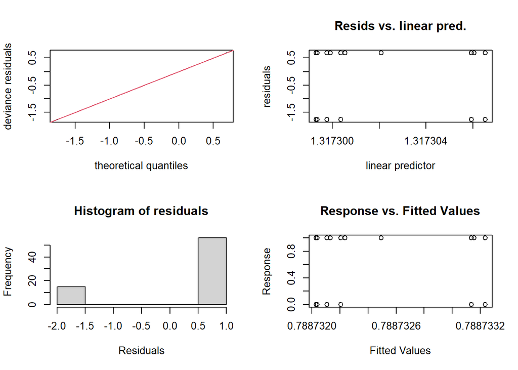

```r
cdat<-dat%>%
  filter(SpeciesCode_cap=="SCHK" & Treatment_cap=="Control" & Release_Location_cap == "Barrier Dam Launch")%>%
  dplyr::select(
    rec,
    Fish_ID,
    run_year_cap,
    DOY_cap,
    Temp_C_cap,
    Release_Location_cap,
    RKM_cap,
    Capture_Location_recap,
    survey_ID_cap
                )%>%
  mutate(run_year_cap = factor(run_year_cap))

m1<-gam(rec ~
          1
          #+ s(run_year_cap,bs="re")
          + s(DOY_cap,bs="ps",k=10,m=1)
          #+ s(RKM_cap,by=run_year_cap,bs="ps",k=3,m=1)
          #+ ti(RKM_cap,DOY_cap,by=run_year_cap,bs="ps",k=12,m=2)
          + s(survey_ID_cap,bs="re",m=1)
          #+ RKM_cap
          ,family = binomial(link="logit")
          ,data=cdat
    )

cat("\\begin{verbatim}")
cat(print("Summary GAM results for probability of recapture for control coho"))
try(cat(print(summary(m1)),silent = T))
cat(print("GAM Goodness of Fit check for probability of recapture for control coho"))
try(cat(print(gam.check(m1)),silent = T))
```

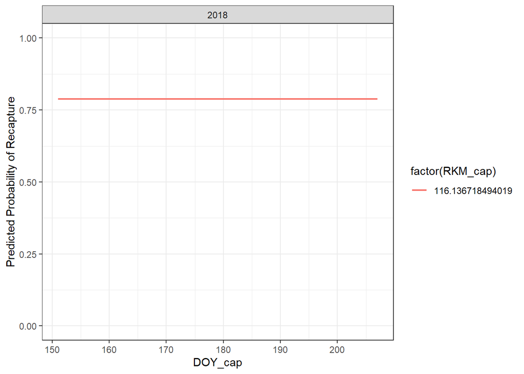

```
## \begin{verbatim}[1] "Summary GAM results for probability of recapture for control coho"
## Summary GAM results for probability of recapture for control coho
## Family: binomial
## Link function: logit
##
## Formula:
## rec ~ 1 + s(DOY_cap, bs = "ps", k = 10, m = 1) + s(survey_ID_cap,
##     bs = "re", m = 1)
##
## Parametric coefficients:
##             Estimate Std. Error z value Pr(>|z|)
## (Intercept)   1.3173     0.2907   4.531 5.88e-06 ***
## ---
## Signif. codes:  0 '***' 0.001 '**' 0.01 '*' 0.05 '.' 0.1 ' ' 1
##
## Approximate significance of smooth terms:
##                        edf Ref.df Chi.sq p-value
## s(DOY_cap)       2.332e-05      8      0   0.725
## s(survey_ID_cap) 5.531e-07      1      0   0.763
##
## R-sq.(adj) =  -1.45e-07   Deviance explained = 1.9e-05%
## UBRE = 0.059432  Scale est. = 1         n = 71
## Error in cat(print(summary(m1)), silent = T) :
##   argument 1 (type 'list') cannot be handled by 'cat'
## [1] "GAM Goodness of Fit check for probability of recapture for control coho"
## GAM Goodness of Fit check for probability of recapture for control coho
## Method: UBRE   Optimizer: outer newton
## full convergence after 10 iterations.
## Gradient range [-4.62281e-07,-1.416197e-08]
## (score 0.05943213 & scale 1).
## Hessian positive definite, eigenvalue range [1.416196e-08,4.622671e-07].
## Model rank =  11 / 11
##
## Basis dimension (k) checking results. Low p-value (k-index<1) may
## indicate that k is too low, especially if edf is close to k'.
##
##                        k'      edf k-index p-value
## s(DOY_cap)       9.00e+00 2.33e-05    0.96    0.42
## s(survey_ID_cap) 1.00e+00 5.53e-07    0.96    0.41
## $mfrow
## [1] 2 2
##
## Error in cat(print(gam.check(m1)), silent = T) :
##   argument 1 (type 'list') cannot be handled by 'cat'
## \end{verbatim}
```

```r
cat("\\end{verbatim}")


newdat<-expand.grid(
  DOY_cap = seq(from=min(cdat$DOY_cap),to=max(cdat$DOY_cap)),
  run_year_cap = unique(cdat$run_year_cap),
  RKM_cap = unique(cdat$RKM_cap),
  survey_ID_cap = 0
  )%>%
  as_tibble()

preds=data.frame(preds=predict(newdata=newdat,m1,var="preds",type = "response", exclude = '(survey_ID_cap,bs="re",m=1)'))%>%
  as_tibble()

newdat<-newdat%>%
  bind_cols(preds)


ggplot(newdat,aes(x=DOY_cap,y=preds,color=factor(RKM_cap)))+
  geom_line(size=0.8)+
  facet_wrap(~run_year_cap,ncol=1)+
  ylim(0,1)+
  ylab("Predicted Probability of Recapture")+
  theme_bw()
```

# Simulation GLM for dummy variable survival analysis

```r
n<-2000 #total fish
n_t=round(0.5*n) #number of treatment fish
TC<-data.frame(TC=c(rep(0,(n-n_t)),rep(1,n_t))) #dummy vector for Treatment and controls
k_rec<-3 #count of global covariates including global intercept
k_surv<-2 #count of global covariates
b<-rnorm(k_rec+k_surv,0,1) # beta's for global covariates
x<-bind_cols(data.frame("int"=rep(1,n)),as_tibble(mvrnorm(n=n,mu=rep(0,k_rec+k_surv-1), Sigma=diag(k_rec+k_surv-1)))) #design matrix


#=========
# binomial
#=========
logit_pred<-data.frame(logit_pred=as.matrix(x[,1:k_rec]) %*% b[1:k_rec] + #global covariates and intercept
    as.matrix((as.matrix(x[,(k_rec+1):(k_rec+k_surv)]) * cbind(TC,TC))) %*% b[(k_rec+1):(k_rec+k_surv)]) #treatment covariates (interaction with dummy variable)

#=========
# R2R
#=========
logit_pred<-data.frame(logit_pred=logit(ilogit(as.matrix(x[,1:k_rec]) %*% b[1:k_rec] + #global covariates and intercept
                                               as.matrix((as.matrix(x[,(k_rec+1):(k_rec+k_surv)]) * cbind(TC,TC))) %*% b[(k_rec+1):(k_rec+k_surv)]))) #treatment covariates (interaction with dummy variable)

dat<-x%>%
  bind_cols(TC)%>%
  bind_cols(logit_pred)%>%
  as_tibble()%>%
  mutate(
  rec = rbinom(n=n, size=1, prob= ilogit(logit_pred))
  )


#==========
# BRMS fits
#==========
fmla<-as.formula(paste0("rec ~ ",paste("V",1:(k_rec-1),sep="",collapse =   "+ "),"+", paste("TC : V",(k_rec):(k_rec+k_surv-1),sep="",collapse =   "+ ")))

#m1<-brm(fmla, family = bernoulli(link="logit"),data=dat,cores = 4,chains=4,iter=2000,warmup = 1000)
#m1<-brm(fmla, family = poisson(link="log"),data=dat,cores = 4,chains=4,iter=2000,warmup = 1000)
m1<-glm(fmla, family = binomial(link="logit"),data=dat)

cat("\\begin{verbatim}")
cat(print("Summary GLM results with simulated data"))
try(cat(print(summary(m1)),silent = T))
cat(print("Actual parameter values used to generate simulated data"))
print(b)
cat("\\end{verbatim}")
```

```
## \begin{verbatim}[1] "Summary GLM results with simulated data"
## Summary GLM results with simulated data
## Call:
## glm(formula = fmla, family = binomial(link = "logit"), data = dat)
##
## Deviance Residuals:
##      Min        1Q    Median        3Q       Max
## -2.74372  -0.43470   0.07635   0.48758   3.01773
##
## Coefficients:
##             Estimate Std. Error z value Pr(>|z|)
## (Intercept)  0.53171    0.07112   7.476 7.67e-14 ***
## V1           2.82786    0.13246  21.348  < 2e-16 ***
## V2           1.57389    0.09380  16.779  < 2e-16 ***
## TC:V3       -0.64415    0.10311  -6.247 4.18e-10 ***
## TC:V4       -0.67655    0.10243  -6.605 3.98e-11 ***
## ---
## Signif. codes:  0 '***' 0.001 '**' 0.01 '*' 0.05 '.' 0.1 ' ' 1
##
## (Dispersion parameter for binomial family taken to be 1)
##
##     Null deviance: 2751.3  on 1999  degrees of freedom
## Residual deviance: 1340.5  on 1995  degrees of freedom
## AIC: 1350.5
##
## Number of Fisher Scoring iterations: 6
##
## Error in cat(print(summary(m1)), silent = T) :
##   argument 1 (type 'list') cannot be handled by 'cat'
## [1] "Actual parameter values used to generate simulated data"
## Actual parameter values used to generate simulated data[1]  0.5720303  2.7095657  1.4147098 -0.5946095 -0.4357817
## \end{verbatim}
```

# A stan model for fitting R2R models with no covariates

```r
processFile(file.path("stan_models", "R2R.stan"))
```

```
## data{
##   int n;//number of observations (fish)
##   int rec[n]; //bernoulli variable indicating if an individual recovered
##   int TC[n]; //dummy variable indicating if an individual is a T or C
## }
## parameters{
##   real<lower=0,upper=1> p[2];
## }
## transformed parameters{
##   //logit(p[i]) =
## }
## model{
##   //priors
##   p ~ beta(1,1);
##   //likelihoods
##   for(i in 1:n){
##     if(TC[i]==1){
##       rec[i] ~ bernoulli(p[1]);
##     }else{
##       rec[i] ~ bernoulli(p[1]*p[2]);
##     }
##   }
## }
```